# Tasks for homework 3

1. Calculate the predictions for some selected observations
2. Then, calculate the decomposition of these predictions with LIME using the package of choice, e.g. in Python: lime, dalex, in R: iml, localModel.
3. Compare LIME for various observations in the dataset. How stable are these explanations?
4. Compare LIME with the explanations obtained using SHAP. What are the main differences between them?
5. Compare LIME between at least two different models. Are there any systematic differences across many observations?
6. Comment on the results obtained in (3), (4) and (5)

# Report

Based on the dataset from the previous homeworks, I've trained xgboost model. I've decided to split dataset into two parts: math and portugese as the factors for achieving good grades my be different in this cases.

For the math dataset I've obtained following results:

- recall: 1.0
- precision: 0.142857
- f1: 0.25
- accuracy: 0.333333
- auc: 0.491981

and for the portuguese dataset:

- recall: 1.0
- precision: 0.333333
- f1: 0.5
- accuracy: 0.5
- auc: 0.491133.

For analysing LIME explanaitions, I've chosen two observations for each dataset - one with correct prediction and one with wrong prediction.

Below there are some plots for all examples:

- math correct prediction:

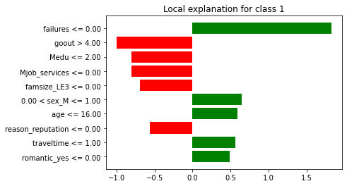

- math wrong prediction:

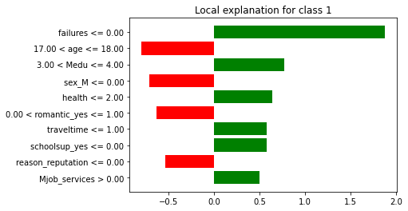

- port correct prediction:

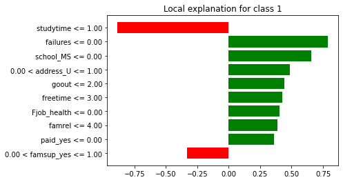

[figure not shown]

The next step is checking the stability of the LIME. I have checked two scenarios of that:

- stability of LIME for the same example
- stability of LIME for various examples.

For the first case we got following results:

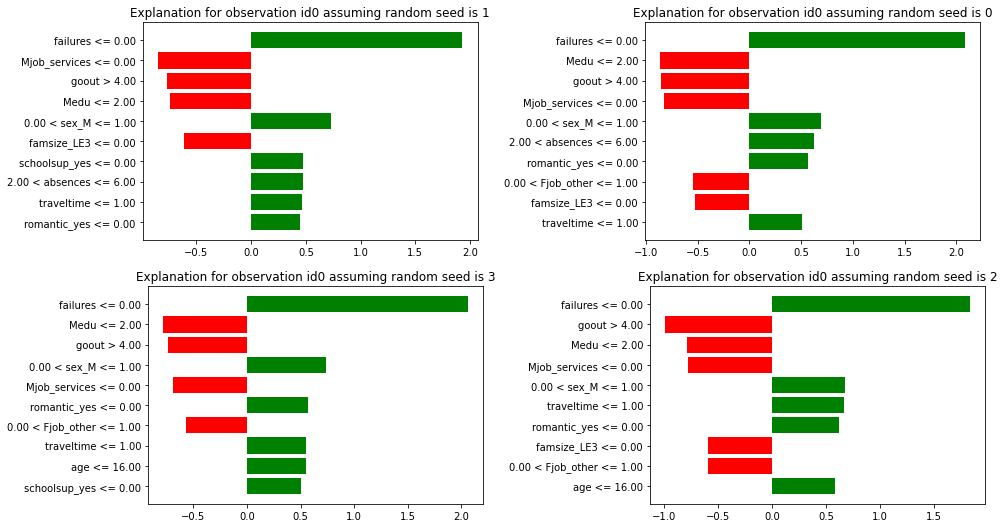

Top 3 features are the same in 3 out of 4 examples, although values are different.

For the wrong prediction we got:

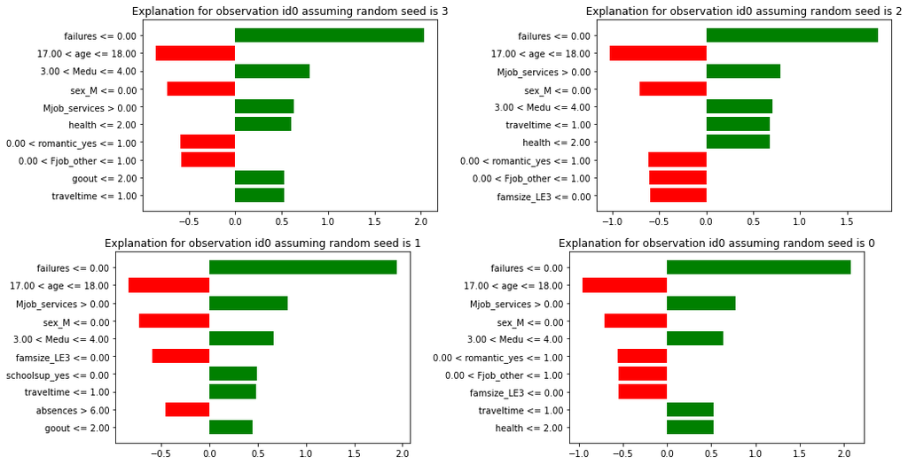

Again top 3 features are rather stable.

For the second case I've randomly chosen 4 obervations. With random seed we got following results:

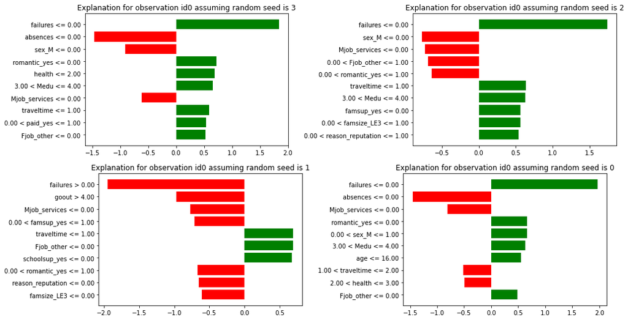

With constant seed:

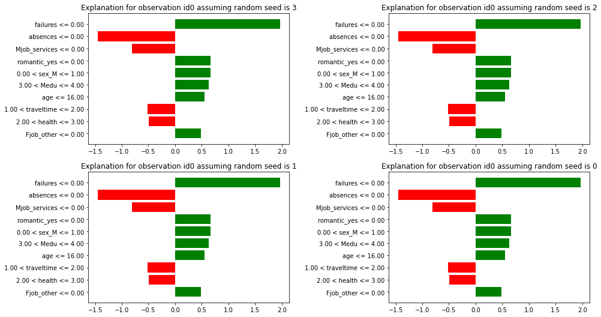

From that experiment we got some important morale -- when explaining the model with LIME we have to take into consideration its instability.

The next step is comparing LIME explanaitions with SHAP:

- Math dataset, correct prediction

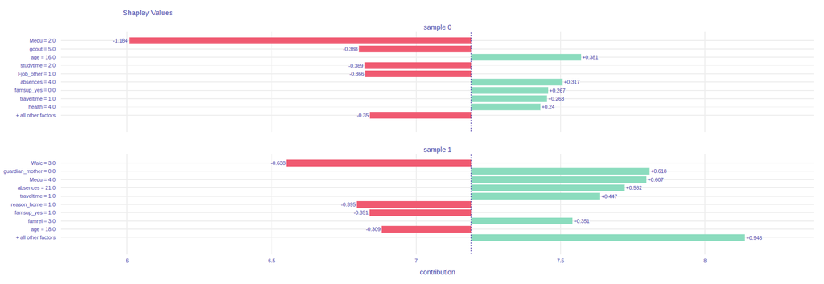

Selected features are different from those selected by LIME. First feature from SHAP is the third in LIME. `Failures` feature which is the first feature in LIME does not appear in the SHAP plot at all.

Math dataset, wrong prediction: similarly to the correct prediction.

For the portuguese dataset:

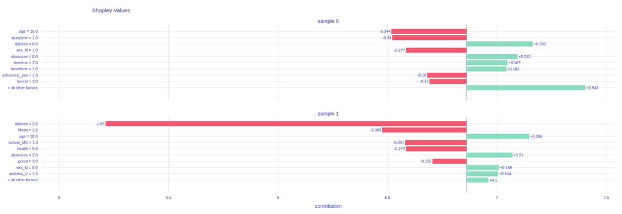

The last but not least, we were supposed to compare LIME explanaitions across different models. The second model I've chosen is SVM.

For the math dataset we got following LIME features

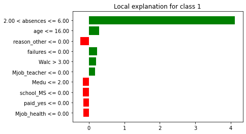

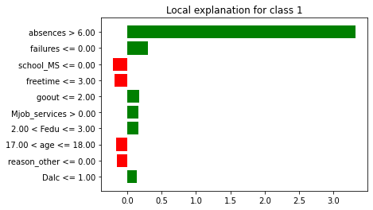

Chosen features and their values are drastically different than the one's from xgboost model. We can see that the most influential feature in SVM model is `absences`. The other attributes don't have much influence on the prediction.

For the portuguese model we have:

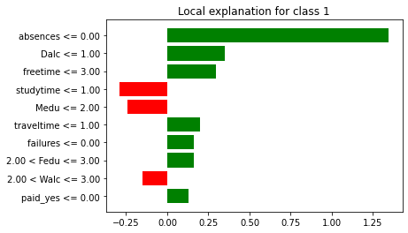

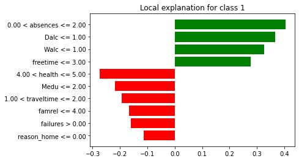

For portuguese dataset the features also differ from the xgboost model, but values of the first feature are not as drastic as in the math dataset case.

# Appendix

### Setup

```python
! pip install dalex >/dev/null 2>&1
! pip install 'xgboost==1.6.2' >/dev/null 2>&1
! pip install lime >/dev/null 2>&1
! pip install shap >/dev/null 2>&1
```

```python
import pandas as pd
from sklearn.model_selection import train_test_split
import matplotlib.pyplot as plt
from sklearn.linear_model import LogisticRegression
import xgboost as xgb
import numpy as np
import dalex
import shap
from sklearn.metrics import classification_report
from sklearn.svm import SVC
import lime
import lime.lime_tabular
```

```python
from google.colab import files
files.upload()
print(' ')
```

Upload widget is only available when the cell has been executed in the current browser session. Please rerun this cell to enable.

```
Saving archive.zip to archive.zip
```

```python
! unzip archive.zip -d data
```

```
Archive:  archive.zip
  inflating: data/Maths.csv
  inflating: data/Portuguese.csv
```

### Data preparation

```python
df_math = pd.read_csv('/content/data/Maths.csv')
df_port = pd.read_csv('/content/data/Portuguese.csv')
```

```python
def get_one_hot_columns(df):
  one_hot_columns = []
  for column in df.columns:
    if df[column].dtype == 'object':
      one_hot_columns.append(column)
  return one_hot_columns
```

```python
df_math = pd.get_dummies(df_math, columns=get_one_hot_columns(df_math), drop_first=True)
df_port = pd.get_dummies(df_port, columns=get_one_hot_columns(df_port), drop_first=True)
```

```python
df_math = df_math[df_math['G3'] != 20]
df_math = df_math[df_math['G3'] != 4]
df_port = df_port[df_port['G3'] != 1]
df_port = df_port[df_port['G3'] != 5]
```

```python
X_math = df_math.copy()
X_math = X_math.drop(['G3', 'G2', 'G1'], axis=1)
y_math = df_math['G3']

X_port = df_port.copy()
X_port = X_port.drop(['G3', 'G2', 'G1'], axis=1)
y_port = df_port['G3']
```

```python
prev_math = list(set(y_math))
prev_port = list(set(y_port))
```

```python
from sklearn.preprocessing import LabelEncoder
le = LabelEncoder()
y_math = le.fit_transform(y_math)
y_port = le.fit_transform(y_port)
```

```python
encoded_math = list(set(y_math))
encoded_port = list(set(y_port))
```

```python
def label_encoding(prev, encoded):
  encoded_to_prev_label = {}
  for p, e in zip(prev, encoded):
    encoded_to_prev_label[e] = p
  return encoded_to_prev_label
```

```python
encoded_to_prev_label_math = label_encoding(prev_math, encoded_math)
encoded_to_prev_label_port = label_encoding(prev_port, encoded_port)
```

```python
X_math_train, X_math_test, y_math_train, y_math_test = train_test_split(X_math, y_math, test_size=0.2, random_state=42, stratify=y_math)
X_port_train, X_port_test, y_port_train, y_port_test = train_test_split(X_port, y_port, test_size=0.2, random_state=42, stratify=y_port)
```

### Model for math

```python
xgb_math = xgb.XGBClassifier(
    n_estimators=700,
    max_depth=15  ,
    use_label_encoder=False,
    eval_metric="logloss",
    enable_categorical=False,
    tree_method="hist"
)
```

```python
xgb_math.fit(X_math_train, y_math_train)
```

```
XGBClassifier(base_score=0.5, booster='gbtree', callbacks=None,
              colsample_bylevel=1, colsample_bynode=1, colsample_bytree=1,
              early_stopping_rounds=None, enable_categorical=False,
              eval_metric='logloss', gamma=0, gpu_id=-1,
              grow_policy='depthwise', importance_type=None,
              interaction_constraints='', learning_rate=0.300000012,
              max_bin=256, max_cat_to_onehot=4, max_delta_step=0, max_depth=15,
              max_leaves=0, min_child_weight=1, missing=nan,
              monotone_constraints='()', n_estimators=700, n_jobs=0,
              num_parallel_tree=1, objective='multi:softprob', predictor='auto',
              random_state=0, reg_alpha=0, ...)
```

```python
# sample1 = np.random.randint(len(X_math_test))
# sample2 = np.random.randint(len(X_math_test))
# print(sample1, sample2)
```

```python
sample1 = 3
sample2 = 4
```

```python
xgb_math.predict(X_math_test.take([sample1])).item(), y_math_test.take([sample1]).item()
```

```
(6, 6)
```

```python
xgb_math.predict(X_math_test.take([sample2])).item(), y_math_test.take([sample2]).item()
```

```
(9, 14)
```

```python
X_math_sample = X_math_test.take([sample1, sample2])
X_math_sample = X_math_sample.reset_index(drop=True)
```

```python
def pf_xgboost_classifier(model, df):
    return np.argmax(model.predict_proba(df),axis=-1)

explainer = dalex.Explainer(xgb_math, X_math_test, y_math_test, predict_function=pf_xgboost_classifier, label='xgboost')
```

```
Preparation of a new explainer is initiated

  -> data              : 79 rows 39 cols
  -> target variable   : 79 values
  -> model_class       : xgboost.sklearn.XGBClassifier (default)
  -> label             : xgboost
  -> predict function  : <function pf_xgboost_classifier at 0x7f714e049830> will be used
  -> predict function  : Accepts pandas.DataFrame and numpy.ndarray.
  -> predicted values  : min = 0.0, mean = 7.19, max = 15.0
  -> model type        : classification will be used (default)
  -> residual function : difference between y and yhat (default)
  -> residuals         : min = -12.0, mean = -0.506, max = 9.0
  -> model_info        : package xgboost

A new explainer has been created!
```

```python
explainer.model_performance()
```

|  | recall | precision | f1 | accuracy | auc |
| --- | --- | --- | --- | --- | --- |
| xgboost | 1.0 | 0.142857 | 0.25 | 0.333333 | 0.491981 |

### LIME for math

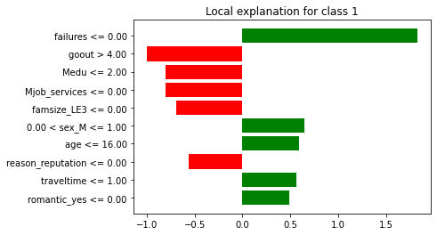

```python
explanation = explainer.predict_surrogate(X_math_sample.loc[[0]])
explanation.result
explanation.plot()
```

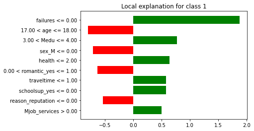

```python
explanation = explainer.predict_surrogate(X_math_sample.loc[[1]])
explanation.result
fig = explanation.plot()
```

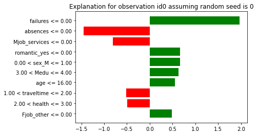

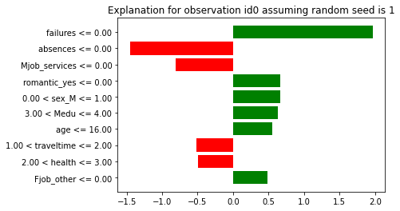

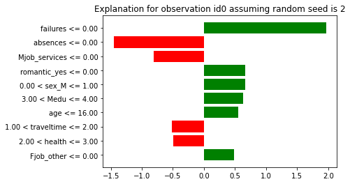

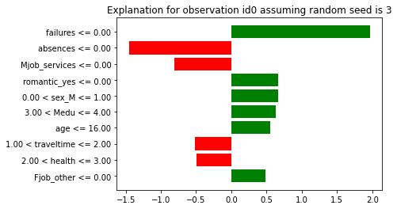

```python
import random
import matplotlib.pyplot as plt

for seed in range(4):
    random.seed(0)
    np.random.seed(0)
    exp = explainer.predict_surrogate(X_math_test.sample(n=1))
    exp.plot(return_figure=True)
    plt.title(f'Explanation for observation id0 assuming random seed is {seed}')
```

### Comparing with SHAP

```python
explainer.predict(X_math_sample)
shap_attributions = [explainer.predict_parts(X_math_sample.iloc[[i]], type="shap", label=f'sample {i}') for i in range(len(X_math_sample))]
shap_attributions[0].plot(shap_attributions[1::])
```

[interactive chart not shown]

### SVM model

```python
from sklearn import svm
clf = svm.SVC()
clf.fit(X_math_train, y_math_train)
```

```
SVC()
```

```python
def pf_svm_classifier(model, df):
    return model.predict(df)
explainer_svm = dalex.Explainer(clf, X_math_test, y_math_test, predict_function=pf_svm_classifier, label='svm')
```

```
Preparation of a new explainer is initiated

  -> data              : 79 rows 39 cols
  -> target variable   : 79 values
  -> model_class       : sklearn.svm._classes.SVC (default)
  -> label             : svm
  -> predict function  : <function pf_svm_classifier at 0x7f714e0490e0> will be used
  -> predict function  : Accepts pandas.DataFrame and numpy.ndarray.
  -> predicted values  : min = 0.0, mean = 3.01, max = 7.0
  -> model type        : classification will be used (default)
  -> residual function : difference between y and yhat (default)
  -> residuals         : min = -5.0, mean = 3.67, max = 15.0
  -> model_info        : package sklearn

A new explainer has been created!
```

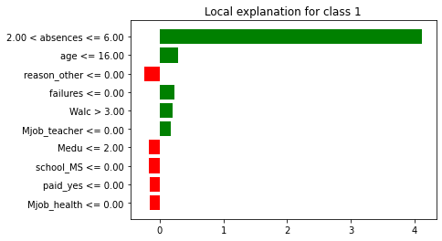

```python
explanation = explainer_svm.predict_surrogate(X_math_sample.loc[[0]])
explanation.result
explanation.plot()
```

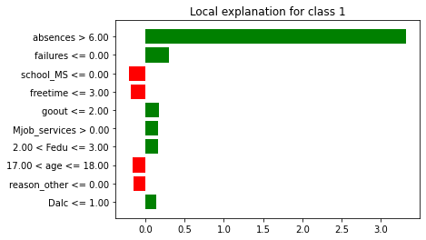

```python
explanation = explainer_svm.predict_surrogate(X_math_sample.loc[[1]])
explanation.result
explanation.plot()
```

### Model for port

```python
xgb_port = xgb.XGBClassifier(
    n_estimators=700,
    max_depth=15  ,
    use_label_encoder=False,
    eval_metric="logloss",
    enable_categorical=False,
    tree_method="hist"
)
```

```python
xgb_port.fit(X_port_train, y_port_train)
```

```
XGBClassifier(base_score=0.5, booster='gbtree', callbacks=None,
              colsample_bylevel=1, colsample_bynode=1, colsample_bytree=1,
              early_stopping_rounds=None, enable_categorical=False,
              eval_metric='logloss', gamma=0, gpu_id=-1,
              grow_policy='depthwise', importance_type=None,
              interaction_constraints='', learning_rate=0.300000012,
              max_bin=256, max_cat_to_onehot=4, max_delta_step=0, max_depth=15,
              max_leaves=0, min_child_weight=1, missing=nan,
              monotone_constraints='()', n_estimators=700, n_jobs=0,
              num_parallel_tree=1, objective='multi:softprob', predictor='auto',
              random_state=0, reg_alpha=0, ...)
```

```python
sample1 = 16
sample2 = 5
```

```python
xgb_port.predict(X_port_test.take([sample1])).item(), y_port_test.take([sample1]).item()
```

```
(7, 7)
```

```python
xgb_port.predict(X_port_test.take([sample2])).item(), y_port_test.take([sample2]).item()
```

```
(5, 3)
```

```python
X_port_sample = X_port_test.take([sample1, sample2])
X_port_sample = X_port_sample.reset_index(drop=True)
```

```python
def pf_xgboost_classifier(model, df):
    return np.argmax(model.predict_proba(df),axis=-1)

explainer = dalex.Explainer(xgb_port, X_port_test, y_port_test, predict_function=pf_xgboost_classifier, label='xgboost')
```

```
Preparation of a new explainer is initiated

  -> data              : 130 rows 39 cols
  -> target variable   : 130 values
  -> model_class       : xgboost.sklearn.XGBClassifier (default)
  -> label             : xgboost
  -> predict function  : <function pf_xgboost_classifier at 0x7f714cb5d200> will be used
  -> predict function  : Accepts pandas.DataFrame and numpy.ndarray.
  -> predicted values  : min = 0.0, mean = 6.86, max = 13.0
  -> model type        : classification will be used (default)
  -> residual function : difference between y and yhat (default)
  -> residuals         : min = -8.0, mean = 0.146, max = 8.0
  -> model_info        : package xgboost

A new explainer has been created!
```

```python
explainer.model_performance()
```

|  | recall | precision | f1 | accuracy | auc |
| --- | --- | --- | --- | --- | --- |
| xgboost | 1.0 | 0.333333 | 0.5 | 0.5 | 0.491133 |

### LIME for port

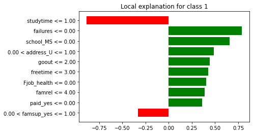

```python
explanation = explainer.predict_surrogate(X_port_sample.loc[[0]])
explanation.result
explanation.plot()
```

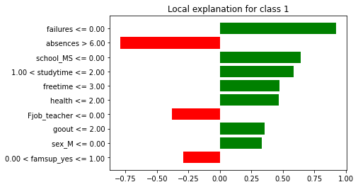

```python
explanation = explainer.predict_surrogate(X_math_sample.loc[[1]])
explanation.result
fig = explanation.plot()
```

### SHAP for port

```python
explainer.predict(X_port_sample)
shap_attributions = [explainer.predict_parts(X_port_sample.iloc[[i]], type="shap", label=f'sample {i}') for i in range(len(X_port_sample))]
shap_attributions[0].plot(shap_attributions[1::])
```

[interactive chart not shown]

### SVM model

```python
clf = svm.SVC()
clf.fit(X_port_train, y_port_train)
```

```
SVC()
```

```python
def pf_svm_classifier(model, df):
    return model.predict(df)
explainer_svm = dalex.Explainer(clf, X_port_test, y_port_test, predict_function=pf_svm_classifier, label='svm')
```

```
Preparation of a new explainer is initiated

  -> data              : 130 rows 39 cols
  -> target variable   : 130 values
  -> model_class       : sklearn.svm._classes.SVC (default)
  -> label             : svm
  -> predict function  : <function pf_svm_classifier at 0x7f714c982f80> will be used
  -> predict function  : Accepts pandas.DataFrame and numpy.ndarray.
  -> predicted values  : min = 5.0, mean = 6.48, max = 8.0
  -> model type        : classification will be used (default)
  -> residual function : difference between y and yhat (default)
  -> residuals         : min = -5.0, mean = 0.523, max = 6.0
  -> model_info        : package sklearn

A new explainer has been created!
```

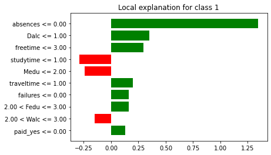

```python
explanation = explainer_svm.predict_surrogate(X_port_sample.loc[[0]])
explanation.result
explanation.plot()
```

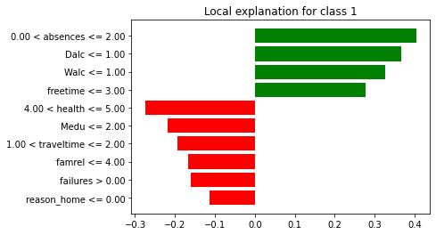

```python
explanation = explainer_svm.predict_surrogate(X_port_sample.loc[[1]])
explanation.result
explanation.plot()
```